# Objectif

L'objectif de ce projet et de construire un modèle de scoring qui traduit le risque qu'a un client de faire défaut sur le prêt qui lui est accordé.

Par la suite, les prédictions de ce modèle devront être exploitables sur une API de visualisation de données, et les résultats devront être interprétés par un outil expliquant les résultats obtenus.

Ce notebook contient le pré-processing des données ainsi que la construction de plusieurs modèles, la sélection du plus pertinent de ces derniers, et, pour finir, présente le fonctionnement de l'interpréteur.

# Chargement des packages

```python
%matplotlib inline

import numpy as np
import matplotlib.pyplot as plt
from matplotlib import cm
from mpl_toolkits import mplot3d
import pandas as pd
import seaborn as sns
import os
import missingno as msno
import warnings
import time
from urllib import request
from zipfile import ZipFile
from sklearn.model_selection import GroupShuffleSplit
from sklearn import preprocessing
import datetime
import tensorflow as tf
from tensorflow.keras.layers import Input, Embedding, Reshape, Dense, BatchNormalization, Masking, LSTM
from tensorflow.keras.models import Model
from sklearn.preprocessing import LabelEncoder, StandardScaler, OneHotEncoder
from sklearn.model_selection import GroupShuffleSplit, train_test_split
from sklearn.model_selection import cross_val_score
from sklearn.ensemble import ExtraTreesClassifier
from sklearn.metrics import plot_roc_curve, roc_curve, auc, precision_recall_curve
import pickle
import hyperopt
from hyperopt import fmin, tpe, hp, STATUS_OK, Trials, space_eval
import xgboost as xgb
from random import seed
import shap

pd.options.mode.chained_assignment = None
warnings.simplefilter(action='ignore', category=FutureWarning)

# ----- Paramètres -----

## Nom du dossier data
path = "./data"
## Nom du fichier zip
filepath = path + "/prj7_data.zip"
## Source du fichier zip
zip_url = "https://storage.googleapis.com/kaggle-competitions-data/kaggle-v2/9120/860599/bundle/archive.zip?GoogleAccessId=web-data@kaggle-161607.iam.gserviceaccount.com&Expires=1620896494&Signature=sExz0pdzSGvmb6V0LSOB27qrh%2BIB2ZaVOYLGj2wAds8eSSdEn%2FhQEN%2FXh1vPXEiXLYwoVM1QLc5E6t7ujJnJuspXqhqRD9zUSSar6y0F%2Fi1gDMk1klzSCL0mLUNr1%2BkLohz3L%2BNikWROA7rXceZH7Hi5nL7QBluzkL2G8bNseDn6YFp%2FlRkK%2FY18Plyxx2mU3%2FuDmAeamc6NZENSDcPgKoxWxz0wWBw%2BXFcsIBvcLx3tSs%2Bdg4HDzi0xyFtBtXMyiACmFTZyLcwkDfqFAAUZSBYsV%2Bvp%2Foe7aPC0jYLYo7O9Nv40wjfhj3QRa95ipqDOxB4cSXW%2FqlT0Ai4isYNuPA%3D%3D&response-content-disposition=attachment%3B+filename%3Dhome-credit-default-risk.zip"
```

# Chargement des datasets

```python
# Création du dossier data
if not os.path.exists(path):
    os.makedirs(path)

# Téléchargement et dézippage des datasets
if not os.path.exists(filepath):
    r = requests.get(zip_url, allow_redirects=True)

    open(filepath, 'wb').write(r.content)

    with ZipFile(filepath, "r") as zipObj:
        zipObj.extractall(path)
```

```python
application_test = pd.read_csv("./data/application_test.csv")
application_train = pd.read_csv("./data/application_train.csv")
bureau = pd.read_csv("./data/bureau.csv")
bureau_balance = pd.read_csv("./data/bureau_balance.csv")
credit_card_balance = pd.read_csv("./data/credit_card_balance.csv")
HomeCredit_columns_description = pd.read_csv("./data/HomeCredit_columns_description.csv", engine = "python")
installments_payments = pd.read_csv("./data/installments_payments.csv")
POS_CASH_balance = pd.read_csv("./data/POS_CASH_balance.csv")
previous_application = pd.read_csv("./data/previous_application.csv")
```

# Fonctions personnalisées

```python
def abline(x,y,xlims, ax, color = "black", linestyle = "--"):
    xrange = np.arange(xlims[0],xlims[1],0.1)
    A = np.vstack([x, np.ones(len(x))]).T
    k, b = np.linalg.lstsq(A, y)[0]
    ax.plot(xrange, k*xrange + b, color = color, linestyle = linestyle)

def describe_dataset(dataset):
    print("Le dataset contient {} observations et {} variables".format(dataset.shape[0], dataset.shape[1]))
    print("\n")
    if dataset.shape[1] <= 20:
        print("Variables du dataset :")
        print(dataset.columns.tolist())
        print("\n")
    print("Vue d'ensemble des valeurs manquantes :")
    print(dataset.isna().sum())


def create_batch(dataframe, time_start, t_colname="MONTHS_BALANCE", id_colname="SK_ID_CURR"):
    # Calculate number of time blocks
    oldest_time = -96
    n_time_blocks = -(oldest_time - time_start) + 1

    # Define which months to iterate on
    time_range = [-timestamp for timestamp in range(-time_start, -oldest_time + 1)]
    # Define list of client IDs
    id_list = dataframe[id_colname].unique().tolist()
    id_list.sort()

    # Figure out output cube shape
    observations_shape = len(id_list)
    features_shape = dataframe.drop(columns = [t_colname, id_colname]).shape[1]

    # Create output cube
    output_cube = np.zeros((observations_shape, features_shape, n_time_blocks))

    # Fill cube
    for x, unique_id in enumerate(id_list):
        client_info = dataframe.loc[dataframe[id_colname] == unique_id, :]
        for z, month in enumerate(time_range):
            if month in client_info[t_colname].tolist():
                monthly_client_info = client_info.loc[client_info[t_colname] == month, :].drop(columns = [t_colname, id_colname])
                output_cube[x, :, z] = monthly_client_info

    return(output_cube)

def dataset_preprocessing(dataframe, categorical_features):
    for categorical_var in categorical_features:
        encoder = preprocessing.LabelEncoder()
        dataframe[categorical_var] = encoder.fit_transform(dataframe[categorical_var])
    return dataframe

def create_embedding_model(categorical_variable_vector, input_layer_name):
    variable_nbins = len(categorical_variable_vector.unique())
    input_layer = Input(shape = (1,), name = input_layer_name)
    embedding_layer = Embedding(variable_nbins, 36,
                            trainable = True,
                           embeddings_initializer = tf.initializers.random_normal
                           )(input_layer)
    reshape_layer = Reshape(target_shape = (36,))(embedding_layer)
    return(input_layer, reshape_layer)

def make_all_embedders(dataset, categorical_variables_list, numerical_variables_list):
    models = []
    inputs = []
    for categorical_var in categorical_variables_list:
        input_layer_name = categorical_var + "_input"
        (inpt, outpt) = create_embedding_model(dataset[categorical_var], input_layer_name = input_layer_name)
        inputs.append(inpt)
        models.append(outpt)
    num_inpt = Input(shape = (len(numerical_variables_list)), name = "num_input")
    inputs.append(num_inpt)
    models.append(num_inpt)
    return(inputs, models)

def numstats(df, group_var, df_name):

    # Remove id variables other than grouping variable
    for col in df:
        if col != group_var and 'SK_ID' in col:
            df = df.drop(columns = col)

    group_ids = df[group_var]
    numeric_df = df.select_dtypes('number')
    numeric_df[group_var] = group_ids

    # Group by the specified variable and calculate the statistics
    agg = numeric_df.groupby(group_var).agg(['count', 'mean', 'max', 'min', 'sum']).reset_index()

    # Need to create new column names
    columns = [group_var]

    # Iterate through the variables names
    for var in agg.columns.levels[0]:
        # Skip the grouping variable
        if var != group_var:
            # Iterate through the stat names
            for stat in agg.columns.levels[1][:-1]:
                # Make a new column name for the variable and stat
                columns.append('%s_%s_%s' % (df_name, var, stat))

    agg.columns = columns
    return agg

def catstats(df, group_var, df_name):

    # Select the categorical columns
    categorical = pd.get_dummies(df.select_dtypes('object'))

    # Make sure to put the identifying id on the column
    categorical[group_var] = df[group_var]

    # Groupby the group var and calculate the sum and mean
    categorical = categorical.groupby(group_var).agg(['sum', 'mean'])

    column_names = []

    # Iterate through the columns in level 0
    for var in categorical.columns.levels[0]:
        # Iterate through the stats in level 1
        for stat in ['count', 'count_norm']:
            # Make a new column name
            column_names.append('%s_%s_%s' % (df_name, var, stat))

    categorical.columns = column_names

    return categorical
```

# Exploration et pré-traitement

## Découverte des datasets

```python
dataset_list = [application_test, application_train, bureau, bureau_balance, credit_card_balance,
               HomeCredit_columns_description, installments_payments, POS_CASH_balance, previous_application]
dataset_list_names = ["application_test", "application_train", "bureau", "bureau_balance", "credit_card_balance",
               "HomeCredit_columns_description", "installments_payments", "POS_CASH_balance", "previous_application"]
```

```python
for dataset, dataset_name in zip(dataset_list, dataset_list_names):
    print("Exploration du dataset {}".format(dataset_name))
    describe_dataset(dataset)
    print("\n")
    print("---------------------------------")
    print("\n")
```

```
Exploration du dataset application_test
Le dataset contient 48744 observations et 121 variables


Vue d'ensemble des valeurs manquantes :
SK_ID_CURR                       0
NAME_CONTRACT_TYPE               0
CODE_GENDER                      0
FLAG_OWN_CAR                     0
FLAG_OWN_REALTY                  0
                              ...
AMT_REQ_CREDIT_BUREAU_DAY     6049
AMT_REQ_CREDIT_BUREAU_WEEK    6049
AMT_REQ_CREDIT_BUREAU_MON     6049
AMT_REQ_CREDIT_BUREAU_QRT     6049
AMT_REQ_CREDIT_BUREAU_YEAR    6049
Length: 121, dtype: int64


---------------------------------


Exploration du dataset application_train
Le dataset contient 307511 observations et 122 variables


Vue d'ensemble des valeurs manquantes :
SK_ID_CURR                        0
TARGET                            0
NAME_CONTRACT_TYPE                0
CODE_GENDER                       0
FLAG_OWN_CAR                      0
                              ...
AMT_REQ_CREDIT_BUREAU_DAY     41519
AMT_REQ_CREDIT_BUREAU_WEEK    41519
AMT_REQ_CREDIT_BUREAU_MON     41519
AMT_REQ_CREDIT_BUREAU_QRT     41519
AMT_REQ_CREDIT_BUREAU_YEAR    41519
Length: 122, dtype: int64

```

[output cut: 185 more lines]

```
SELLERPLACE_AREA                     0
NAME_SELLER_INDUSTRY                 0
CNT_PAYMENT                     372230
NAME_YIELD_GROUP                     0
PRODUCT_COMBINATION                346
DAYS_FIRST_DRAWING              673065
DAYS_FIRST_DUE                  673065
DAYS_LAST_DUE_1ST_VERSION       673065
DAYS_LAST_DUE                   673065
DAYS_TERMINATION                673065
NFLAG_INSURED_ON_APPROVAL       673065
dtype: int64


---------------------------------
```

```python
if not os.path.exists("./databook.xlsx"):
    HomeCredit_columns_description.to_excel("./databook.xlsx")
```

```python
application_test.columns
```

```
Index(['SK_ID_CURR', 'NAME_CONTRACT_TYPE', 'CODE_GENDER', 'FLAG_OWN_CAR',
       'FLAG_OWN_REALTY', 'CNT_CHILDREN', 'AMT_INCOME_TOTAL', 'AMT_CREDIT',
       'AMT_ANNUITY', 'AMT_GOODS_PRICE',
       ...
       'FLAG_DOCUMENT_18', 'FLAG_DOCUMENT_19', 'FLAG_DOCUMENT_20',
       'FLAG_DOCUMENT_21', 'AMT_REQ_CREDIT_BUREAU_HOUR',
       'AMT_REQ_CREDIT_BUREAU_DAY', 'AMT_REQ_CREDIT_BUREAU_WEEK',
       'AMT_REQ_CREDIT_BUREAU_MON', 'AMT_REQ_CREDIT_BUREAU_QRT',
       'AMT_REQ_CREDIT_BUREAU_YEAR'],
      dtype='object', length=121)
```

```python
application_train.columns
```

```
Index(['SK_ID_CURR', 'TARGET', 'NAME_CONTRACT_TYPE', 'CODE_GENDER',
       'FLAG_OWN_CAR', 'FLAG_OWN_REALTY', 'CNT_CHILDREN', 'AMT_INCOME_TOTAL',
       'AMT_CREDIT', 'AMT_ANNUITY',
       ...
       'FLAG_DOCUMENT_18', 'FLAG_DOCUMENT_19', 'FLAG_DOCUMENT_20',
       'FLAG_DOCUMENT_21', 'AMT_REQ_CREDIT_BUREAU_HOUR',
       'AMT_REQ_CREDIT_BUREAU_DAY', 'AMT_REQ_CREDIT_BUREAU_WEEK',
       'AMT_REQ_CREDIT_BUREAU_MON', 'AMT_REQ_CREDIT_BUREAU_QRT',
       'AMT_REQ_CREDIT_BUREAU_YEAR'],
      dtype='object', length=122)
```

## Valeurs manquantes - Dataset principal

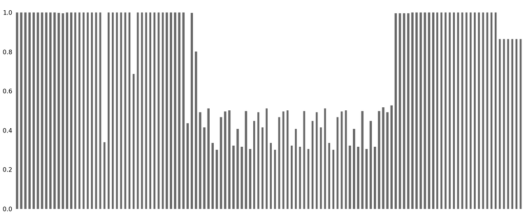

```python
msno.bar(application_train)
```

Le dataset principal contient de nombreuses valeurs manquantes. Nous allons éliminer les colonnes lacunaires à plus de 20%

```python
na_count = application_train.isna().sum()
```

```python
na_count_df = pd.DataFrame()
na_count_df["column"] = na_count.index
na_count_df["nas"] = na_count.values
na_count_df["na_proportion"] = na_count_df["nas"].apply(lambda X : round(X / application_train.shape[0], 2))

drop_cols_list = na_count_df.loc[na_count_df["na_proportion"] >= 0.2, "column"].tolist()
print(len(drop_cols_list))
```

```
51
```

```python
data = application_train.drop(columns = drop_cols_list)
```

Regardons les valeurs manquantes qu'il nous reste

```python
na_count2 = data.isna().sum()
```

```python
na_count2[na_count2 > 0]
```

```
AMT_ANNUITY                      12
AMT_GOODS_PRICE                 278
NAME_TYPE_SUITE                1292
CNT_FAM_MEMBERS                   2
EXT_SOURCE_2                    660
OBS_30_CNT_SOCIAL_CIRCLE       1021
DEF_30_CNT_SOCIAL_CIRCLE       1021
OBS_60_CNT_SOCIAL_CIRCLE       1021
DEF_60_CNT_SOCIAL_CIRCLE       1021
DAYS_LAST_PHONE_CHANGE            1
AMT_REQ_CREDIT_BUREAU_HOUR    41519
AMT_REQ_CREDIT_BUREAU_DAY     41519
AMT_REQ_CREDIT_BUREAU_WEEK    41519
AMT_REQ_CREDIT_BUREAU_MON     41519
AMT_REQ_CREDIT_BUREAU_QRT     41519
AMT_REQ_CREDIT_BUREAU_YEAR    41519
dtype: int64
```

Beaucoup de ces valeurs manquantes sont situées sur des colonnes de compte de jours et signifient "aucun". Nous allons donc remplacer ces valeurs manquantes par des 0. Pour "NAME_TYPE_SUITE", nous imputerons "Unaccompanied" quand l'information n'est pas indiquée, qui serait l'équivalent catégoriel d'un 0.

```python
fillna_values = {}

for column in ["OBS_30_CNT_SOCIAL_CIRCLE", "DEF_30_CNT_SOCIAL_CIRCLE", "OBS_60_CNT_SOCIAL_CIRCLE", "DEF_60_CNT_SOCIAL_CIRCLE",
 "AMT_REQ_CREDIT_BUREAU_HOUR", "AMT_REQ_CREDIT_BUREAU_DAY", "AMT_REQ_CREDIT_BUREAU_WEEK", "AMT_REQ_CREDIT_BUREAU_MON",
    "AMT_REQ_CREDIT_BUREAU_QRT", "AMT_REQ_CREDIT_BUREAU_YEAR"]:
    fillna_values[column] = 0

fillna_values["NAME_TYPE_SUITE"] = "Unaccompanied"

data.fillna(value = fillna_values, inplace = True)
```

AMT_ANNUITY donne des informations sur l'annuité de prêt. Cette information est essentielle dans une étude de prêt ; nous ne pourrons pas faire sans. Par conséquent, nous éliminerons les 12 observations où cette valeur est manquante.

```python
data.dropna(subset = ["AMT_ANNUITY", "AMT_GOODS_PRICE", "CNT_FAM_MEMBERS", "DAYS_LAST_PHONE_CHANGE"], inplace = True)
```

Il nous reste à imputer les valeurs manquantes de "EXT_SOURCE_2" mais nous ne pourrons le faire qu'une fois les jeux d'entraînement et de test définis pour ne pas fausser les données

## Séparation train_test

Pour éviter toute fuite de donnée, nous effectuerons notre séparation selon la colonne "SK_ID_CURR"

```python
inTrain , inTest = next(GroupShuffleSplit(train_size = 0.7, random_state = 42).\
                        split(data, groups = data["SK_ID_CURR"])
                       )
def trainset(dataset, subsetter=inTrain):
    return dataset.iloc[subsetter]
```

```python
X = data.drop(columns = "TARGET")
y_train = trainset(data["TARGET"])
y_test = data["TARGET"].iloc[inTest]
```

```python
X.head()
```

|  | SK_ID_CURR | NAME_CONTRACT_TYPE | CODE_GENDER | FLAG_OWN_CAR | FLAG_OWN_REALTY | CNT_CHILDREN | AMT_INCOME_TOTAL | AMT_CREDIT | AMT_ANNUITY | AMT_GOODS_PRICE | ... | FLAG_DOCUMENT_18 | FLAG_DOCUMENT_19 | FLAG_DOCUMENT_20 | FLAG_DOCUMENT_21 | AMT_REQ_CREDIT_BUREAU_HOUR | AMT_REQ_CREDIT_BUREAU_DAY | AMT_REQ_CREDIT_BUREAU_WEEK | AMT_REQ_CREDIT_BUREAU_MON | AMT_REQ_CREDIT_BUREAU_QRT | AMT_REQ_CREDIT_BUREAU_YEAR |
| --- | --- | --- | --- | --- | --- | --- | --- | --- | --- | --- | --- | --- | --- | --- | --- | --- | --- | --- | --- | --- | --- |
| 0 | 100002 | Cash loans | M | N | Y | 0 | 202500.0 | 406597.5 | 24700.5 | 351000.0 | ... | 0 | 0 | 0 | 0 | 0.0 | 0.0 | 0.0 | 0.0 | 0.0 | 1.0 |
| 1 | 100003 | Cash loans | F | N | N | 0 | 270000.0 | 1293502.5 | 35698.5 | 1129500.0 | ... | 0 | 0 | 0 | 0 | 0.0 | 0.0 | 0.0 | 0.0 | 0.0 | 0.0 |
| 2 | 100004 | Revolving loans | M | Y | Y | 0 | 67500.0 | 135000.0 | 6750.0 | 135000.0 | ... | 0 | 0 | 0 | 0 | 0.0 | 0.0 | 0.0 | 0.0 | 0.0 | 0.0 |
| 3 | 100006 | Cash loans | F | N | Y | 0 | 135000.0 | 312682.5 | 29686.5 | 297000.0 | ... | 0 | 0 | 0 | 0 | 0.0 | 0.0 | 0.0 | 0.0 | 0.0 | 0.0 |
| 4 | 100007 | Cash loans | M | N | Y | 0 | 121500.0 | 513000.0 | 21865.5 | 513000.0 | ... | 0 | 0 | 0 | 0 | 0.0 | 0.0 | 0.0 | 0.0 | 0.0 | 0.0 |

5 rows × 70 columns

```python
X.shape
```

```
(307220, 70)
```

```python
y_train.shape
```

```
(215054,)
```

```python
y_test.shape
```

```
(92166,)
```

```python
trainset(X).shape
```

```
(215054, 70)
```

## Imputation de valeurs manquantes de EXT_SOURCE_2

Nous imputerons les valeurs manquantes en fonction de la médiane dans le jeu d'entraînement

```python
X.fillna(value = {"EXT_SOURCE_2" : trainset(X)["EXT_SOURCE_2"].quantile(0.5)},
         inplace = True)
```

## Duplicats

Nous vérifions ici s'il n'y a aucun duplicat

```python
nrows_prev = X.shape[0]
X.drop_duplicates(subset = "SK_ID_CURR", inplace = True)
print("Suppression de {} duplicats".format(X.shape[0] - nrows_prev))
```

```
Suppression de 0 duplicats
```

# Fusion avec autres tables - Données statiques

## Fusion avec POS_CASH_balance

Nous enrichissons notre dataset principal avec les données de POS_CASH_BALANCE, en extrayant les minima, maxima et médianes des valeurs *day past due* pour chaque client

```python
SK_DPD_DEF_min = POS_CASH_balance.loc[:, ["SK_ID_CURR", "SK_DPD_DEF"]].groupby(by = "SK_ID_CURR").min()
SK_DPD_DEF_min.rename(columns = {"SK_DPD_DEF" : "SK_DPD_DEF_min"}, inplace = True)
```

```python
SK_DPD_DEF_max = POS_CASH_balance.loc[:, ["SK_ID_CURR", "SK_DPD_DEF"]].groupby(by = "SK_ID_CURR").max()
SK_DPD_DEF_max.rename(columns = {"SK_DPD_DEF" : "SK_DPD_DEF_max"}, inplace = True)
```

```python
SK_DPD_DEF_med = POS_CASH_balance.loc[:, ["SK_ID_CURR", "SK_DPD_DEF"]].groupby(by = "SK_ID_CURR").agg(lambda X: np.quantile(X, 0.5))
SK_DPD_DEF_med.rename(columns = {"SK_DPD_DEF" : "SK_DPD_DEF_med"}, inplace = True)
```

```python
SK_DPD_DEF_charac = pd.merge(SK_DPD_DEF_min, SK_DPD_DEF_max, on = "SK_ID_CURR", how = "outer")
SK_DPD_DEF_charac = pd.merge(SK_DPD_DEF_charac, SK_DPD_DEF_med, on = "SK_ID_CURR", how = "outer")
```

```python
X = pd.merge(X, SK_DPD_DEF_charac, on = "SK_ID_CURR", how = "left")
```

```python
X.fillna(value = {"SK_DPD_DEF_min" : trainset(X)["SK_DPD_DEF_min"].quantile(0.5),
                 "SK_DPD_DEF_max" : trainset(X)["SK_DPD_DEF_max"].quantile(0.5),
                 "SK_DPD_DEF_med" : trainset(X)["SK_DPD_DEF_med"].quantile(0.5)},
         inplace = True)
```

## Fusion avec previous_application

Nous ajoutons au dataset principal le montant total qu'un client a emprunté par le passé

```python
loan_history = previous_application.loc[:, ["SK_ID_CURR", "AMT_CREDIT"]].groupby(by = "SK_ID_CURR").sum()
loan_history.rename(columns = {"AMT_CREDIT" : "TOTAL_AMT_CREDIT"}, inplace = True)
```

```python
X = pd.merge(X, loan_history, on = "SK_ID_CURR", how = "left")
```

```python
X.fillna(value = {"TOTAL_AMT_CREDIT" : 0}, inplace = True)
```

## Fusion avec bureau

Bureau contient énormément de données sur les clients, mais malheureusement énormément de valeurs manquantes :

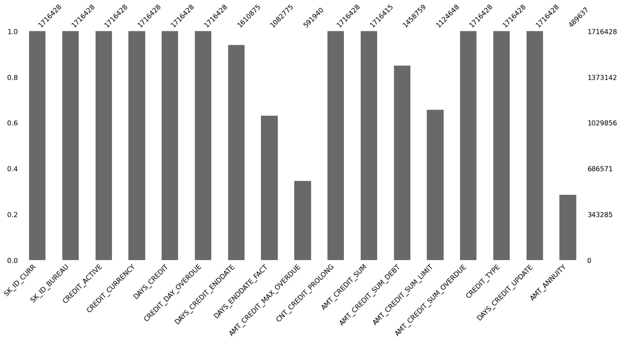

```python
msno.bar(bureau)
```

Pour chaque variable numérique de chaque client, nous extrairons le nombre d'observations, la moyenne, le maximum, le minimum, et la somme totale à l'aide de la fonction personnalisée *numstats*

```python
num_stats_bureau = numstats(bureau.drop(columns = ['SK_ID_BUREAU']), group_var = 'SK_ID_CURR', df_name = 'bureau')
num_stats_bureau.head()
```

|  | SK_ID_CURR | bureau_DAYS_CREDIT_count | bureau_DAYS_CREDIT_mean | bureau_DAYS_CREDIT_max | bureau_DAYS_CREDIT_min | bureau_DAYS_CREDIT_sum | bureau_CREDIT_DAY_OVERDUE_count | bureau_CREDIT_DAY_OVERDUE_mean | bureau_CREDIT_DAY_OVERDUE_max | bureau_CREDIT_DAY_OVERDUE_min | ... | bureau_DAYS_CREDIT_UPDATE_count | bureau_DAYS_CREDIT_UPDATE_mean | bureau_DAYS_CREDIT_UPDATE_max | bureau_DAYS_CREDIT_UPDATE_min | bureau_DAYS_CREDIT_UPDATE_sum | bureau_AMT_ANNUITY_count | bureau_AMT_ANNUITY_mean | bureau_AMT_ANNUITY_max | bureau_AMT_ANNUITY_min | bureau_AMT_ANNUITY_sum |
| --- | --- | --- | --- | --- | --- | --- | --- | --- | --- | --- | --- | --- | --- | --- | --- | --- | --- | --- | --- | --- | --- |
| 0 | 100001 | 7 | -735.000000 | -49 | -1572 | -5145 | 7 | 0.0 | 0 | 0 | ... | 7 | -93.142857 | -6 | -155 | -652 | 7 | 3545.357143 | 10822.5 | 0.0 | 24817.5 |
| 1 | 100002 | 8 | -874.000000 | -103 | -1437 | -6992 | 8 | 0.0 | 0 | 0 | ... | 8 | -499.875000 | -7 | -1185 | -3999 | 7 | 0.000000 | 0.0 | 0.0 | 0.0 |
| 2 | 100003 | 4 | -1400.750000 | -606 | -2586 | -5603 | 4 | 0.0 | 0 | 0 | ... | 4 | -816.000000 | -43 | -2131 | -3264 | 0 | NaN | NaN | NaN | 0.0 |
| 3 | 100004 | 2 | -867.000000 | -408 | -1326 | -1734 | 2 | 0.0 | 0 | 0 | ... | 2 | -532.000000 | -382 | -682 | -1064 | 0 | NaN | NaN | NaN | 0.0 |
| 4 | 100005 | 3 | -190.666667 | -62 | -373 | -572 | 3 | 0.0 | 0 | 0 | ... | 3 | -54.333333 | -11 | -121 | -163 | 3 | 1420.500000 | 4261.5 | 0.0 | 4261.5 |

5 rows × 61 columns

Pour chaque variable catégorielle de chaque client, nous extrairons, pour chaque valeur possible de cette variable, le nombre de fois que cette valeur apparaît et la proportion qu'elle occupe parmi l'intégralité des valeurs, à l'aide de la fonction personnalisée *catstats*

```python
cat_stats_bureau = catstats(bureau, group_var = 'SK_ID_CURR', df_name = 'bureau')
cat_stats_bureau.head()
```

| SK_ID_CURR | bureau_CREDIT_ACTIVE_Active_count | bureau_CREDIT_ACTIVE_Active_count_norm | bureau_CREDIT_ACTIVE_Bad debt_count | bureau_CREDIT_ACTIVE_Bad debt_count_norm | bureau_CREDIT_ACTIVE_Closed_count | bureau_CREDIT_ACTIVE_Closed_count_norm | bureau_CREDIT_ACTIVE_Sold_count | bureau_CREDIT_ACTIVE_Sold_count_norm | bureau_CREDIT_CURRENCY_currency 1_count | bureau_CREDIT_CURRENCY_currency 1_count_norm | ... | bureau_CREDIT_TYPE_Microloan_count | bureau_CREDIT_TYPE_Microloan_count_norm | bureau_CREDIT_TYPE_Mobile operator loan_count | bureau_CREDIT_TYPE_Mobile operator loan_count_norm | bureau_CREDIT_TYPE_Mortgage_count | bureau_CREDIT_TYPE_Mortgage_count_norm | bureau_CREDIT_TYPE_Real estate loan_count | bureau_CREDIT_TYPE_Real estate loan_count_norm | bureau_CREDIT_TYPE_Unknown type of loan_count | bureau_CREDIT_TYPE_Unknown type of loan_count_norm |
| --- | --- | --- | --- | --- | --- | --- | --- | --- | --- | --- | --- | --- | --- | --- | --- | --- | --- | --- | --- | --- | --- |
| 100001 | 3 | 0.428571 | 0 | 0.0 | 4 | 0.571429 | 0 | 0.0 | 7 | 1.0 | ... | 0 | 0.0 | 0 | 0.0 | 0 | 0.0 | 0 | 0.0 | 0 | 0.0 |
| 100002 | 2 | 0.250000 | 0 | 0.0 | 6 | 0.750000 | 0 | 0.0 | 8 | 1.0 | ... | 0 | 0.0 | 0 | 0.0 | 0 | 0.0 | 0 | 0.0 | 0 | 0.0 |
| 100003 | 1 | 0.250000 | 0 | 0.0 | 3 | 0.750000 | 0 | 0.0 | 4 | 1.0 | ... | 0 | 0.0 | 0 | 0.0 | 0 | 0.0 | 0 | 0.0 | 0 | 0.0 |
| 100004 | 0 | 0.000000 | 0 | 0.0 | 2 | 1.000000 | 0 | 0.0 | 2 | 1.0 | ... | 0 | 0.0 | 0 | 0.0 | 0 | 0.0 | 0 | 0.0 | 0 | 0.0 |
| 100005 | 2 | 0.666667 | 0 | 0.0 | 1 | 0.333333 | 0 | 0.0 | 3 | 1.0 | ... | 0 | 0.0 | 0 | 0.0 | 0 | 0.0 | 0 | 0.0 | 0 | 0.0 |

5 rows × 46 columns

Nous obtenons les datasets suivants :

```python
print(num_stats_bureau.shape)
print(cat_stats_bureau.shape)
```

```
(305811, 61)
(305811, 46)
```

Nous les concaténons :

```python
bureau_stats = pd.merge(num_stats_bureau, cat_stats_bureau, left_on = "SK_ID_CURR", right_index = True, how = "outer")
```

```python
bureau_stats.shape
```

```
(305811, 107)
```

Tout comme pour le dataset principal, nous retirons les colonnes lacunaires à plus de 20% :

```python
tempnan = bureau_stats.isna().sum()
```

```python
dropcols_bureau = tempnan[tempnan / bureau_stats.shape[0] > 0.2].index.tolist()
```

```python
bureau_stats.drop(columns = dropcols_bureau, inplace = True)
```

Nous complétons une fois de plus les valeurs manquantes restantes par des 0

```python
bureau_stats.fillna(0, inplace = True)
```

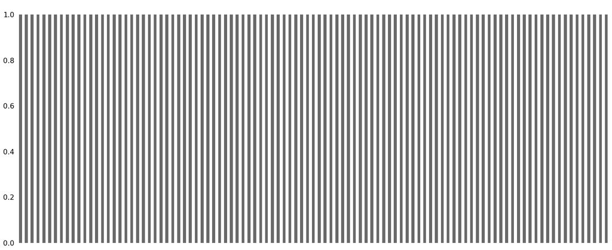

```python
msno.bar(bureau_stats)
```

Nous fusionnons la table obtenue avec le dataset principal :

```python
X = pd.merge(X, bureau_stats, on = "SK_ID_CURR", how = "left")
```

Certains clients de X n'avaient pas d'informations dans bureau. Il serait dommage de simplement éliminer ces observations, donc nous imputons les valeurs manquantes de bureau par des 0

```python
X.fillna(0, inplace = True)
```

# Table credit_card_balance - Données temporelles

credit_card_balance contient énormément d'informations, mais également beaucoup de valeurs manquantes :

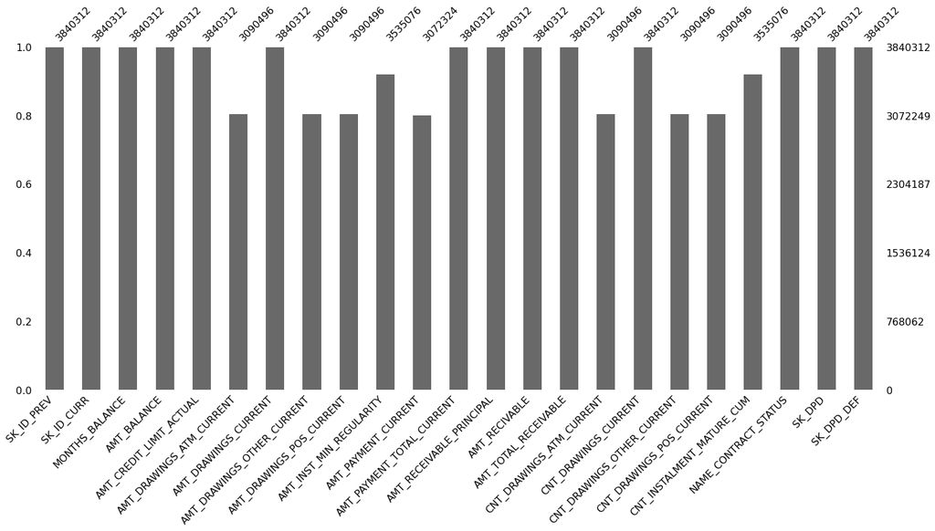

```python
msno.bar(credit_card_balance)
```

Ces données temporelles passeront par la suite par un réseau de neurones qui contiendra une couche de masking. Nous pouvons donc simplement compléter les valeurs manquantes par des 0 lorsque nous n'avons pas d'information.

```python
credit_card_balance.fillna(0, inplace = True)
```

```python
len(credit_card_balance["SK_ID_CURR"].unique())
```

```
103558
```

```python
credit_card_balance.drop(columns = "SK_ID_PREV", inplace = True)
```

On peut alors fusionner cette tables avec X

```python
X_temporal = pd.merge(X, credit_card_balance, on = "SK_ID_CURR", how = "left")
```

```python
X_temporal.sort_values(["SK_ID_CURR", "MONTHS_BALANCE"], inplace = True)
```

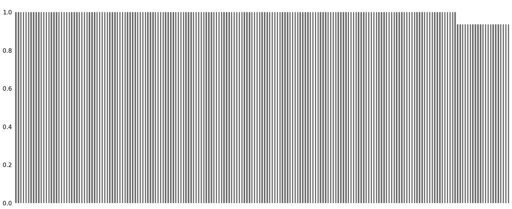

```python
msno.bar(X_temporal)
```

Certains clients n'ont aucune information temporelle. Nous considérerons alors que ces clients ont une seule observation temporelle au moment de la demande de crédit (c'est-à-dire "MONTHS_BALANCE" = -1), uniquement composée de zéros.

```python
fillna_values2 = {}
for colname in ['AMT_BALANCE', 'AMT_CREDIT_LIMIT_ACTUAL', 'AMT_DRAWINGS_ATM_CURRENT','AMT_DRAWINGS_CURRENT',
             'AMT_DRAWINGS_OTHER_CURRENT', 'AMT_DRAWINGS_POS_CURRENT', 'AMT_INST_MIN_REGULARITY', 'AMT_PAYMENT_CURRENT',
             'AMT_PAYMENT_TOTAL_CURRENT', 'AMT_RECEIVABLE_PRINCIPAL', 'AMT_RECIVABLE', 'AMT_TOTAL_RECEIVABLE', 'CNT_DRAWINGS_ATM_CURRENT',
             'CNT_DRAWINGS_CURRENT', 'CNT_DRAWINGS_OTHER_CURRENT', 'CNT_DRAWINGS_POS_CURRENT', 'CNT_INSTALMENT_MATURE_CUM',
             'SK_DPD', 'SK_DPD_DEF']:
    fillna_values2[colname] = 0
fillna_values2['MONTHS_BALANCE'] = -1
fillna_values2['NAME_CONTRACT_STATUS'] = "Active"
```

```python
X_temporal.fillna(value = fillna_values2, inplace = True)
```

## Portée des mois d'observation

```python
X_temporal["MONTHS_BALANCE"].min()
```

```
-96.0
```

```python
X_temporal["MONTHS_BALANCE"].max()
```

```
-1.0
```

## Encodage de Name_contract_status

```python
le_NCS = preprocessing.LabelEncoder()
le_NCS.fit(X_temporal['NAME_CONTRACT_STATUS'])
```

```
LabelEncoder()
```

```python
X_temporal['NAME_CONTRACT_STATUS'] = le_NCS.transform(X_temporal['NAME_CONTRACT_STATUS'])
```

## Création des batch : fonctionnement de la fonction *create_batch*

Nous allons prendre les valeurs temporelles et convertir les tables en cubes de dimensions :

- x : ID client, une ligne par client
- y : Valeur des variables pour un mois m donné
- z : Mois d'observation m

Le cube est créé grâce à la fonction create_batch.

Regardonc comment cette fonction agit sur un échantillon que nous appellerons "temp" :

```python
temporal_cols = ['SK_ID_CURR', 'MONTHS_BALANCE', 'AMT_BALANCE', 'AMT_CREDIT_LIMIT_ACTUAL', 'AMT_DRAWINGS_ATM_CURRENT','AMT_DRAWINGS_CURRENT',
             'AMT_DRAWINGS_OTHER_CURRENT', 'AMT_DRAWINGS_POS_CURRENT', 'AMT_INST_MIN_REGULARITY', 'AMT_PAYMENT_CURRENT',
             'AMT_PAYMENT_TOTAL_CURRENT', 'AMT_RECEIVABLE_PRINCIPAL', 'AMT_RECIVABLE', 'AMT_TOTAL_RECEIVABLE', 'CNT_DRAWINGS_ATM_CURRENT',
             'CNT_DRAWINGS_CURRENT', 'CNT_DRAWINGS_OTHER_CURRENT', 'CNT_DRAWINGS_POS_CURRENT', 'CNT_INSTALMENT_MATURE_CUM',
                 'SK_DPD', 'SK_DPD_DEF']
```

```python
temp = X_temporal.loc[:, temporal_cols]
```

```python
temp = temp.head(1000)
```

```python
temp.head()
```

|  | SK_ID_CURR | MONTHS_BALANCE | AMT_BALANCE | AMT_CREDIT_LIMIT_ACTUAL | AMT_DRAWINGS_ATM_CURRENT | AMT_DRAWINGS_CURRENT | AMT_DRAWINGS_OTHER_CURRENT | AMT_DRAWINGS_POS_CURRENT | AMT_INST_MIN_REGULARITY | AMT_PAYMENT_CURRENT | ... | AMT_RECEIVABLE_PRINCIPAL | AMT_RECIVABLE | AMT_TOTAL_RECEIVABLE | CNT_DRAWINGS_ATM_CURRENT | CNT_DRAWINGS_CURRENT | CNT_DRAWINGS_OTHER_CURRENT | CNT_DRAWINGS_POS_CURRENT | CNT_INSTALMENT_MATURE_CUM | SK_DPD | SK_DPD_DEF |
| --- | --- | --- | --- | --- | --- | --- | --- | --- | --- | --- | --- | --- | --- | --- | --- | --- | --- | --- | --- | --- | --- |
| 0 | 100002 | -1.0 | 0.0 | 0.0 | 0.0 | 0.0 | 0.0 | 0.0 | 0.0 | 0.0 | ... | 0.0 | 0.0 | 0.0 | 0.0 | 0.0 | 0.0 | 0.0 | 0.0 | 0.0 | 0.0 |
| 1 | 100003 | -1.0 | 0.0 | 0.0 | 0.0 | 0.0 | 0.0 | 0.0 | 0.0 | 0.0 | ... | 0.0 | 0.0 | 0.0 | 0.0 | 0.0 | 0.0 | 0.0 | 0.0 | 0.0 | 0.0 |
| 2 | 100004 | -1.0 | 0.0 | 0.0 | 0.0 | 0.0 | 0.0 | 0.0 | 0.0 | 0.0 | ... | 0.0 | 0.0 | 0.0 | 0.0 | 0.0 | 0.0 | 0.0 | 0.0 | 0.0 | 0.0 |
| 8 | 100006 | -6.0 | 0.0 | 270000.0 | 0.0 | 0.0 | 0.0 | 0.0 | 0.0 | 0.0 | ... | 0.0 | 0.0 | 0.0 | 0.0 | 0.0 | 0.0 | 0.0 | 0.0 | 0.0 | 0.0 |
| 5 | 100006 | -5.0 | 0.0 | 270000.0 | 0.0 | 0.0 | 0.0 | 0.0 | 0.0 | 0.0 | ... | 0.0 | 0.0 | 0.0 | 0.0 | 0.0 | 0.0 | 0.0 | 0.0 | 0.0 | 0.0 |

5 rows × 21 columns

Créons un batch allant du mois -1 jusqu'au maximum :

```python
tempcube = create_batch(temp, -1)
```

Regardons l'apparence du cube

```python
tempcube.shape
```

```
(124, 19, 96)
```

On voit que les valeurs correspondent bien à celles du dataset :

```python
tempcube[3, :, 0]
```

```
array([     0., 270000.,      0.,      0.,      0.,      0.,      0.,
            0.,      0.,      0.,      0.,      0.,      0.,      0.,
            0.,      0.,      0.,      0.,      0.])
```

```python
temp.loc[(temp["SK_ID_CURR"] == 100006) & (temp["MONTHS_BALANCE"] == -1), 'AMT_BALANCE':]
```

|  | AMT_BALANCE | AMT_CREDIT_LIMIT_ACTUAL | AMT_DRAWINGS_ATM_CURRENT | AMT_DRAWINGS_CURRENT | AMT_DRAWINGS_OTHER_CURRENT | AMT_DRAWINGS_POS_CURRENT | AMT_INST_MIN_REGULARITY | AMT_PAYMENT_CURRENT | AMT_PAYMENT_TOTAL_CURRENT | AMT_RECEIVABLE_PRINCIPAL | AMT_RECIVABLE | AMT_TOTAL_RECEIVABLE | CNT_DRAWINGS_ATM_CURRENT | CNT_DRAWINGS_CURRENT | CNT_DRAWINGS_OTHER_CURRENT | CNT_DRAWINGS_POS_CURRENT | CNT_INSTALMENT_MATURE_CUM | SK_DPD | SK_DPD_DEF |
| --- | --- | --- | --- | --- | --- | --- | --- | --- | --- | --- | --- | --- | --- | --- | --- | --- | --- | --- | --- |
| 4 | 0.0 | 270000.0 | 0.0 | 0.0 | 0.0 | 0.0 | 0.0 | 0.0 | 0.0 | 0.0 | 0.0 | 0.0 | 0.0 | 0.0 | 0.0 | 0.0 | 0.0 | 0.0 | 0.0 |

## Création du batch

```python
X_temporal = X_temporal.loc[:, temporal_cols]
```

```python
nrows_prev = X_temporal.shape[0]
X_temporal.drop_duplicates(subset = ["SK_ID_CURR", "MONTHS_BALANCE"], inplace = True)
print("Suppression de {} duplicats".format(nrows_prev - X_temporal.shape[0]))
```

```
Suppression de 5035 duplicats
```

```python
X_temporal.shape
```

```
(3442842, 21)
```

```python
if os.path.exists("./data/pickle_cube"):
    with open("./data/pickle_cube", 'rb') as file:
        print("Chargement du pickle")
        X_batch = pickle.load(file)
else:
    start_clock = time.time()
    X_batch = create_batch(X_temporal, -1)
    print("Batch généré en {}s".format(round(time.time() - start_clock)))
```

```
Chargement du pickle
```

```python
if not os.path.exists("./data/pickle_cube"):
    with open("./data/pickle_cube", 'wb') as file:
            pickle.dump(X_batch, file)
```

```python
X_batch.shape
```

```
(307220, 19, 96)
```

```python
X_train_batch = X_batch[inTrain, :, :]
```

```python
X_train_batch.shape
```

```
(215054, 19, 96)
```

# Métriques

## Contexte

Nous sommes dans un cas de classification binaire avec deux classes déséquilibrées. Par conséquent, l'exactitude n'est pas la métrique la plus adaptée. En effet, un modèle faisant une classification exclusive aurait une exactitude de 90% sans pour autant avoir de plus-value.

L'aire sous la courbe ROC est une métrique intéressante, dans le sens où elle traduit la capacité de notre modèle d'avoir une bonne sensibilité (que nous appellerons recall pour le reste de ce notebook) en sacrifiant peu de sa spécificité. Malheureusement, la faiblesse de cette métrique réside dans le fait qu'une bonne aire sous la courbe roc ne garantit pas une bonne précision. En effet, si les classes sont fortement déséquilibrées, il est possible d'avoir un bon recall et une bonne spécificité tout en ayant une précision de moins de 50%.

Cela signifie que nous détecterons la plupart des futurs défauts, mais que la majorité des détections se font sur des clients qui n'auraient au final pas fait défaut.

Mal interprétés, les résultats peuvent alors justifier le refus d'octroi de crédit à tort, ce qui, en plus de la perte d'un potentiel client, pose de forts problèmes d'éthique.

## Choix

Nous choisirons d'entraîner selon l'aire sous la courbe ROC. Nous choisirons ensuite une valeur de recall en fonction de la coudée de la courbe ROC, où l'augmentation du recall viendrait au prix de beaucoup de spécificité.

Ensuite, à l'aide d'un set de validation, nous choisirons un seuil qui nous permet d'obtenir le score de recall choisi.

Nous vérifierons ensuite cela sur un set de test.

Ce score peut alors être considéré comme un indicateur de risque. Plutôt que de refuser l'octroi de crédit, on peut considérer que les clients au delà du seuil ont un fort risque de défaut, et que le crédit peut alors tout de même être octroyé en ajoutant une assurance.

# Définition des variables

Nous allons ici séparer les variables numériques des variables catégorielles

```python
numcols = X.select_dtypes('number').columns.tolist()
```

```python
idcols = ["SK_ID_CURR"]
binary_cat_cols = ['FLAG_MOBIL', 'FLAG_EMP_PHONE', 'FLAG_WORK_PHONE', 'FLAG_CONT_MOBILE', 'FLAG_PHONE', 'FLAG_EMAIL','REGION_RATING_CLIENT',
                   'REGION_RATING_CLIENT_W_CITY', 'REG_REGION_NOT_LIVE_REGION', 'REG_REGION_NOT_WORK_REGION', 'LIVE_REGION_NOT_WORK_REGION',
                   'REG_CITY_NOT_LIVE_CITY', 'REG_CITY_NOT_WORK_CITY', 'LIVE_CITY_NOT_WORK_CITY', 'FLAG_DOCUMENT_2', 'FLAG_DOCUMENT_3',
                   'FLAG_DOCUMENT_4', 'FLAG_DOCUMENT_5', 'FLAG_DOCUMENT_6', 'FLAG_DOCUMENT_7', 'FLAG_DOCUMENT_8', 'FLAG_DOCUMENT_9',
                   'FLAG_DOCUMENT_10', 'FLAG_DOCUMENT_11', 'FLAG_DOCUMENT_12', 'FLAG_DOCUMENT_13', 'FLAG_DOCUMENT_14', 'FLAG_DOCUMENT_15',
                   'FLAG_DOCUMENT_16', 'FLAG_DOCUMENT_17', 'FLAG_DOCUMENT_18', 'FLAG_DOCUMENT_19', 'FLAG_DOCUMENT_20', 'FLAG_DOCUMENT_21']
no_info_cols = ["WEEKDAY_APPR_PROCESS_START", "HOUR_APPR_PROCESS_START"]
```

```python
catcols = list(set(X.columns.tolist()).difference(numcols))
catcols = list(set(catcols).difference({'WEEKDAY_APPR_PROCESS_START'}))
```

```python
catcols += binary_cat_cols
```

```python
numcols = list(set(numcols).difference(set(idcols + binary_cat_cols + no_info_cols)))
```

```python
X.shape[1] - (len(idcols)+len(catcols)+len(numcols)+len(no_info_cols))
```

```
0
```

# Entraînement du réseau de neurones

Nous allons ici entraîner un réseau de neurones à l'architecture suivante :

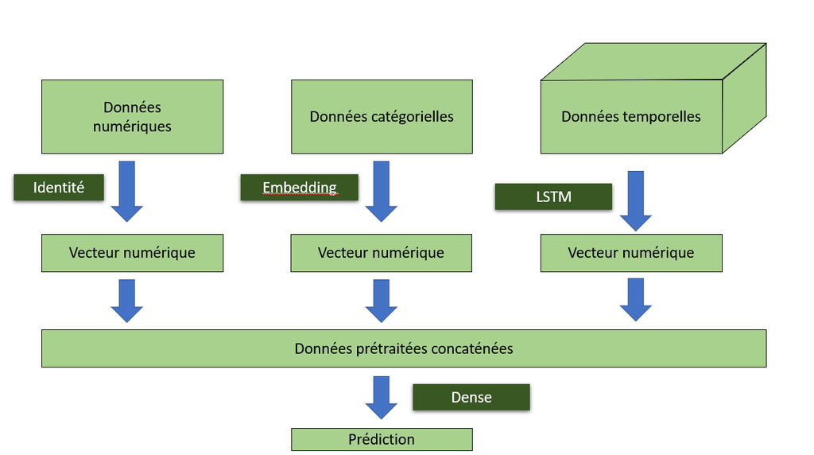

- Les variables numériques passeront par un réseau identité
- Les variables catégorielles passeront par un réseau d'embedding
- Les variables temporelles passeront par un réseau LSTM
- Les trois sorties seront concaténées et passeront par une couche Dense finale

Nous ferons pour cela appel à plusieurs fonctions personnalisées :

- *dataset_preprocessing* qui convertit les catégories textuelles en catégories numériques. Par exemple "homme" / "femme" deviendra 0/1
- *make all embedders* qui créer les inputs et outputs numériques et catégoriels

```python
X_enc = dataset_preprocessing(X, catcols)
```

```python
inputs, models = make_all_embedders(X_enc, catcols, numcols)
```

```python
temporal_input = Input(name = "temporal_input", shape = (19, 96))
temporal_input_masked = Masking(mask_value=0.)(temporal_input)

temporal_lstm = LSTM(19, activation="relu")(temporal_input_masked)

inputs.append(temporal_input)
models.append(temporal_lstm)
```

```python
merged_models = tf.keras.layers.concatenate(models)
```

```python
dense_layer_1 = Dense(1000)(merged_models)
batchnorm_layer_1 = BatchNormalization()(dense_layer_1)
dense_layer_2 = Dense(1000)(batchnorm_layer_1)
batchnorm_layer_2 = BatchNormalization()(dense_layer_2)

prediction_layer = Dense(1, activation = "sigmoid")(batchnorm_layer_2)

final_model = Model(inputs = inputs, outputs = prediction_layer)
```

```python
final_model.summary()
```

```
Model: "model"
__________________________________________________________________________________________________
Layer (type)                    Output Shape         Param #     Connected to
==================================================================================================
NAME_TYPE_SUITE_input (InputLay [(None, 1)]          0
__________________________________________________________________________________________________
NAME_CONTRACT_TYPE_input (Input [(None, 1)]          0
__________________________________________________________________________________________________
CODE_GENDER_input (InputLayer)  [(None, 1)]          0
__________________________________________________________________________________________________
NAME_HOUSING_TYPE_input (InputL [(None, 1)]          0
__________________________________________________________________________________________________
NAME_INCOME_TYPE_input (InputLa [(None, 1)]          0
__________________________________________________________________________________________________
FLAG_OWN_CAR_input (InputLayer) [(None, 1)]          0
__________________________________________________________________________________________________
NAME_FAMILY_STATUS_input (Input [(None, 1)]          0
__________________________________________________________________________________________________
ORGANIZATION_TYPE_input (InputL [(None, 1)]          0
__________________________________________________________________________________________________
NAME_EDUCATION_TYPE_input (Inpu [(None, 1)]          0
__________________________________________________________________________________________________
FLAG_OWN_REALTY_input (InputLay [(None, 1)]          0
__________________________________________________________________________________________________
FLAG_MOBIL_input (InputLayer)   [(None, 1)]          0
__________________________________________________________________________________________________
FLAG_EMP_PHONE_input (InputLaye [(None, 1)]          0
__________________________________________________________________________________________________
FLAG_WORK_PHONE_input (InputLay [(None, 1)]          0
__________________________________________________________________________________________________
FLAG_CONT_MOBILE_input (InputLa [(None, 1)]          0
__________________________________________________________________________________________________
FLAG_PHONE_input (InputLayer)   [(None, 1)]          0
__________________________________________________________________________________________________
FLAG_EMAIL_input (InputLayer)   [(None, 1)]          0
__________________________________________________________________________________________________
REGION_RATING_CLIENT_input (Inp [(None, 1)]          0
__________________________________________________________________________________________________
REGION_RATING_CLIENT_W_CITY_inp [(None, 1)]          0
__________________________________________________________________________________________________
```

[output cut: 282 more lines]

```
__________________________________________________________________________________________________
dense (Dense)                   (None, 1000)         1731000     concatenate[0][0]
__________________________________________________________________________________________________
batch_normalization (BatchNorma (None, 1000)         4000        dense[0][0]
__________________________________________________________________________________________________
dense_1 (Dense)                 (None, 1000)         1001000     batch_normalization[0][0]
__________________________________________________________________________________________________
batch_normalization_1 (BatchNor (None, 1000)         4000        dense_1[0][0]
__________________________________________________________________________________________________
dense_2 (Dense)                 (None, 1)            1001        batch_normalization_1[0][0]
==================================================================================================
Total params: 2,755,829
Trainable params: 2,751,829
Non-trainable params: 4,000
__________________________________________________________________________________________________
```

Nous créons ici notre métrique mesurant l'aire sous la courbe ROC. Elle apparaîtra sous les noms "auc_2" et "val_auc_2" dans l'entraînement.

```python
roc_metric = tf.keras.metrics.AUC(
    num_thresholds=200, curve='ROC',
    summation_method='interpolation', name='auc_2', dtype=None,
    thresholds=None, multi_label=False, label_weights=None,
)
```

Les données étant déséquilibrées, nous définissons les poids de chaque classe :

```python
y_train[y_train == 0].shape[0] / y_train[y_train == 1].shape[0]
```

```
11.411496508339585
```

```python
class_weight = {0: 1.,
                1: 11.
               }
```

## Définition des sets de sub_train et sub_eval

En plus de la séparation train/test, nous aurons besoin d'un sous-jeu d'entraînement et un sous-jeu de validation pour l'entraînement du réseau :

```python
X_enc_train = trainset(X_enc)
```

```python
inSubTrain , inSubEval = next(GroupShuffleSplit(train_size = 0.8, random_state = 42).\
                        split(X_enc_train, groups = X_enc_train["SK_ID_CURR"])
                       )
```

```python
X_enc_subtrain = trainset(X_enc_train, subsetter=inSubTrain)
X_enc_subeval = trainset(X_enc_train, subsetter=inSubEval)
```

```python
X_subtrain_batch = X_train_batch[inSubTrain, :, :]
X_subeval_batch = X_train_batch[inSubEval, :, :]
```

```python
y_enc_subtrain = trainset(y_train, subsetter=inSubTrain)
y_enc_subeval = trainset(y_train, subsetter=inSubEval)
```

## Entraînement du modèle

```python
input_dict = {}
for categorical_var in catcols:
    keyname = categorical_var + "_input"
    input_dict[keyname] = X_enc_subtrain[categorical_var]
input_dict["num_input"] = X_enc_subtrain[numcols]
input_dict["temporal_input"] = X_subtrain_batch

eval_dict = {}
for categorical_var in catcols:
    keyname = categorical_var + "_input"
    eval_dict[keyname] = X_enc_subeval[categorical_var]
eval_dict["num_input"] = X_enc_subeval[numcols]
eval_dict["temporal_input"] = X_subeval_batch
```

```python
tf.config.run_functions_eagerly(True)
```

```python
train_model = True
```

```python
final_model.compile(loss = "binary_crossentropy", metrics = ["accuracy", roc_metric], optimizer = "adam")
```

```python
if os.path.exists("./data/final_model_full"):
    final_model = tf.keras.models.load_model("./data/final_model_full")
```

```python
callback = tf.keras.callbacks.EarlyStopping(monitor='val_loss', patience=10, min_delta = 0.001,
                                            restore_best_weights = True)
chkpt = tf.keras.callbacks.ModelCheckpoint(filepath = './data/model_weights_checkpoint',
                                                    monitor='val_auc_2',
                                                    verbose=0,
                                                    save_best_only=True,
                                                    save_weights_only=True, mode="max")
```

```python
if train_model :
    final_model.fit(input_dict, y_enc_subtrain, epochs = 50, batch_size = 30000,
                    validation_data = (eval_dict, y_enc_subeval), callbacks = [callback, chkpt],
                    class_weight=class_weight, verbose = 1)
```

```python
save_model = False
```

```python
# Restore
model.load_weights('./data/model_weights_checkpoint')
# Save
if save_model:
    final_model.save("./data/final_model_full", overwrite=True)
```

# Entraînement du modèle XGBoost

Nous ferons appel à l'hyperparamétreur bayésien HyperOpt pour entraîner le modèle XGBoost.

```python
X2 = X.copy()
```

```python
ohe = OneHotEncoder(sparse = False)
X2_cat = pd.DataFrame(ohe.fit_transform(X2[catcols]))
X2_cat.columns = ohe.get_feature_names(catcols)
```

```python
X2_num = pd.DataFrame(StandardScaler().fit_transform(X2[numcols]))
X2_num.columns = numcols
```

```python
X2_comb = pd.concat([X2_num, X2_cat], axis = 1)
```

```python
X2_comb.index = X2["SK_ID_CURR"]
```

```python
X2_comb_train = trainset(X2_comb)
X2_comb_test = trainset(X2_comb, subsetter = inTest)
```

```python
space = {
    'max_depth' : hp.choice('max_depth', range(1, 30, 1)),
    'eta' : hp.quniform('eta', 0, 1, 0.1),
    'learning_rate' : hp.quniform('learning_rate', 0.01, 0.5, 0.01),
    'n_estimators' : hp.choice('n_estimators', range(20, 205, 5)),
    'gamma' : hp.quniform('gamma', 0, 0.50, 0.01),
    'min_child_weight' : hp.quniform('min_child_weight', 1, 10, 1),
    'subsample' : hp.quniform('subsample', 0.1, 1, 0.01),
    'colsample_bytree' : hp.quniform('colsample_bytree', 0.1, 1.0, 0.01),
    'colsample_bylevel' : hp.quniform('colsample_bylevel', 0.1, 1.0, 0.01),
    'colsample_bynode' : hp.quniform('colsample_bynode', 0.1, 1.0, 0.01),
    'max_delta_step' : hp.choice('max_delta_step', range(0, 11, 1))
}
```

```python
seed(0)
best = 0
def hyperparameter_tuning(space):
    global best
    warnings.filterwarnings(action='ignore', category=DeprecationWarning)
    warnings.filterwarnings(action='ignore', category=UserWarning)
    classifier = xgb.XGBClassifier(objective = "binary:logistic",
                            tree_method = 'hist',
                            scale_pos_weight = 11,
                            eta = space['eta'],
                            n_estimators = space['n_estimators'],
                            max_depth = int(space['max_depth']),
                            learning_rate = space['learning_rate'],
                            gamma = space['gamma'],
                            min_child_weight = space['min_child_weight'],
                            subsample = space['subsample'],
                            colsample_bytree = space['colsample_bytree'],
                            colsample_bylevel = space['colsample_bylevel'],
                            colsample_bynode = space['colsample_bynode'],
                            eval_metric = "auc",
                            max_delta_step = space['max_delta_step']
                            )

    classifier.fit(X2_comb_train, y_train.tolist())

    acc = cross_val_score(estimator = classifier, X = X2_comb_train, y = y_train.tolist(),
                              scoring="auc", cv = 10).mean()
    if acc > best:
        best = acc
        print ('new best:', best, space)
    return {'loss': 1-acc, 'status': STATUS_OK}
if os.path.exists("./data/pickle_xgb_hyperparams"):
    with open("./data/pickle_xgb_hyperparams", 'rb') as file:
        xgb_hyperparams = pickle.load(file)
else :
    trials = Trials()
    best = fmin(hyperparameter_tuning, space, algo=tpe.suggest, max_evals=50, trials=trials)
```

```python
if not os.path.exists("./data/pickle_xgb_hyperparams"):
    xgb_hyperparams = space_eval(space, best)
xgb_hyperparams
```

```
{'colsample_bylevel': 0.29,
 'colsample_bynode': 0.98,
 'colsample_bytree': 0.68,
 'eta': 0.8,
 'gamma': 0.41000000000000003,
 'learning_rate': 0.1,
 'max_delta_step': 1,
 'max_depth': 5,
 'min_child_weight': 3.0,
 'n_estimators': 200,
 'subsample': 0.37}
```

```python
if not os.path.exists("./data/pickle_xgb_recall_hyperparams"):
    with open("./data/pickle_xgb_recall_hyperparams", 'wb') as file:
            pickle.dump(xgb_hyperparams, file)
```

```python
modfit_xgb = xgb.XGBClassifier(objective = "binary:logistic",
                               tree_method = 'hist',
                               scale_pos_weight = 11,
                               eval_metric = "auc",
                               **xgb_hyperparams
                              )
modfit_xgb.fit(X2_comb_train, y_train.tolist())
```

```
XGBClassifier(base_score=0.5, booster='gbtree', colsample_bylevel=0.29,
              colsample_bynode=0.98, colsample_bytree=0.68, eta=0.8,
              eval_metric='auc', gamma=0.41000000000000003, gpu_id=-1,
              importance_type='gain', interaction_constraints='',
              learning_rate=0.1, max_delta_step=1, max_depth=5,
              min_child_weight=3.0, missing=nan, monotone_constraints='()',
              n_estimators=200, n_jobs=8, num_parallel_tree=1, random_state=0,
              reg_alpha=0, reg_lambda=1, scale_pos_weight=11, subsample=0.37,
              tree_method='hist', validate_parameters=1, verbosity=None)
```

# Entraînement du modèle Extratree

Pour finir, nous entraînerons également un arbre de décision grâce à HyperOpt.

```python
seed(0)
no_iteration = 0
space = {
    'max_depth': hp.choice('max_depth', range(1, 20)),
    'max_features': hp.choice('max_features', range(1, 70)),
    'n_estimators': hp.choice('n_estimators', range(100, 500)),
    'min_samples_split' : hp.choice('min_samples_split', range(2, 10)),
    'min_samples_leaf' : hp.choice('min_samples_leaf', range(1, 10)),
    'max_leaf_nodes' : hp.choice('max_leaf_nodes', range(2, 10, 2)),
    'criterion': hp.choice('criterion', ["gini", "entropy"])}

best = 0
def hyperparameter_tuning(space):
    global best
    global no_iteration
    no_iteration += 1
    classifier = ExtraTreesClassifier(class_weight = "balanced", **space)

    classifier.fit(X2_comb_train, y_train.tolist())

    acc = cross_val_score(estimator = classifier, X = X2_comb_train, y = y_train.tolist(),
                              scoring="roc_auc", cv = 10).mean()
    if acc > best:
        best = acc
        print ('new best:', best, space)
    elif no_iteration % 10 == 0:
        print ('tracker. current best:', best, space)
    return {'loss': 1-acc, 'status': STATUS_OK}

trials = Trials()
best = fmin(hyperparameter_tuning, space, algo=tpe.suggest, max_evals=100, trials=trials)
```

```python
if not os.path.exists("./data/pickle_extratree_hyperparams"):
    with open("./data/pickle_extratree_hyperparams", 'wb') as file:
            pickle.dump(extratree_hyperparams, file)
else :
    with open("./data/pickle_extratree_hyperparams", 'rb') as file:
            extratree_hyperparams = pickle.load(file)
```

```python
if not os.path.exists("./data/pickle_extratree_hyperparams"):
    extratree_hyperparams = space_eval(space, best)
extratree_hyperparams
```

```
{'criterion': 'entropy',
 'max_depth': 11,
 'max_features': 62,
 'max_leaf_nodes': 8,
 'min_samples_leaf': 1,
 'min_samples_split': 4,
 'n_estimators': 471}
```

```python
modfit_xtree = ExtraTreesClassifier(class_weight = "balanced", **extratree_hyperparams)
modfit_xtree.fit(X2_comb_train, y_train.tolist())
```

```
ExtraTreesClassifier(class_weight='balanced', criterion='entropy', max_depth=11,
                     max_features=62, max_leaf_nodes=8, min_samples_split=4,
                     n_estimators=471)
```

# Evaluation des modèles

Nous regarderons ici l'aire sous la courbe ROC que l'on obtient sur le jeu de test pour chaque modèle et nous sélectionnerons celui qui obtient le meilleur résultat.

## Réseau de neurones

```python
X_test = trainset(X_enc, subsetter = inTest)
X_test_batch = X_batch[inTest, :, :]
test_dict = {}
for categorical_var in catcols:
    keyname = categorical_var + "_input"
    test_dict[keyname] = X_test[categorical_var]
test_dict["num_input"] = X_test[numcols]
test_dict["temporal_input"] = X_test_batch
```

```python
nn_pred = final_model.predict(test_dict, batch_size = 3000)
```

```python
fpr_nn, tpr_nn, threshold_nn = roc_curve(y_test.tolist(), nn_pred)
roc_auc_nn = auc(fpr_nn, tpr_nn)
```

```python
roc_auc_nn
```

```
0.6642798869352211
```

## XGBoost

```python
xgb_pred = modfit_xgb.predict_proba(X2_comb_test)[:, 1]
```

```python
fpr_xgb, tpr_xgb, threshold_xgb = roc_curve(y_test.tolist(), xgb_pred)
roc_auc_xgb = auc(fpr_xgb, tpr_xgb)
```

```python
roc_auc_xgb
```

```
0.7494715392227411
```

## Extratree

```python
extratree_pred = modfit_xtree.predict_proba(X2_comb_test)[:, 1]
fpr_xtree, tpr_xtree, threshold_xtree = roc_curve(y_test.tolist(), extratree_pred)
roc_auc_xtree = auc(fpr_xtree, tpr_xtree)
```

```python
roc_auc_xtree
```

```
0.6920519379394563
```

## Synthèse - Courbes ROC

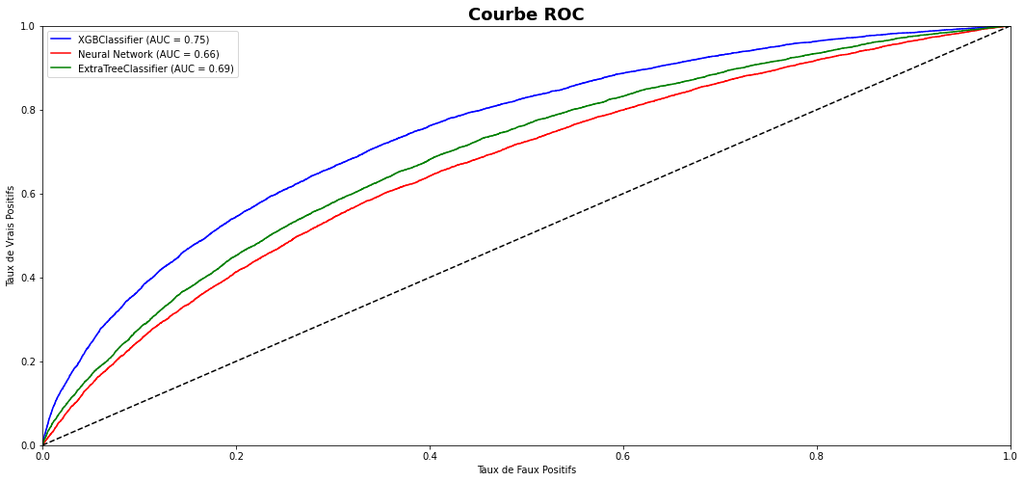

```python
fig, ax = plt.subplots(figsize = (18, 8))
for (classifier, color, fpr, tpr, roc_auc) in zip(["XGBClassifier", "Neural Network", "ExtraTreeClassifier"],
                                                  ["b", "r", "green"],
                                                  [fpr_xgb, fpr_nn, fpr_xtree],
                                                  [tpr_xgb, tpr_nn, tpr_xtree],
                                                  [roc_auc_xgb, roc_auc_nn, roc_auc_xtree]
                                                 ):
    ax.plot(fpr, tpr, color, label = classifier + ' (AUC = %0.2f)' % roc_auc)
abline([0, 1], [0, 1], [0, 1.1], ax=ax)
ax.set_title("Courbe ROC", fontweight = "bold", fontsize = 18);
plt.legend()
plt.xlim([0, 1])
plt.ylim([0, 1])
plt.ylabel('Taux de Vrais Positifs')
plt.xlabel('Taux de Faux Positifs')
plt.show()
```

## Modèle retenu

Nous retiendrons le modèle XGBoost. La courbe ROC montre qu'à partir de 80% de recall, l'amélioration de ce score se fait au prix de beaucoup d'antispécificité. Nous retiendront donc un seuil qui nous permet d'obtenir 80% de recall. Nous allons rechercher ce seuil dans le set de validation et le tester sur le set de test.

### Choix du seuil

```python
X2_comb_subtrain = trainset(X2_comb_train, subsetter=inSubTrain)
X2_comb_subeval = trainset(X2_comb_train, subsetter=inSubEval)
y_subtrain = trainset(y_train, subsetter=inSubTrain)
y_subeval = trainset(y_train, subsetter=inSubEval)
```

```python
modfit_xgb = xgb.XGBClassifier(objective = "binary:logistic",
                               tree_method = 'hist',
                               scale_pos_weight = 11,
                               eval_metric = "auc",
                               **xgb_hyperparams
                              )
modfit_xgb.fit(X2_comb_subtrain, y_subtrain.tolist())
```

```
XGBClassifier(base_score=0.5, booster='gbtree', colsample_bylevel=0.29,
              colsample_bynode=0.98, colsample_bytree=0.68, eta=0.8,
              eval_metric='auc', gamma=0.41000000000000003, gpu_id=-1,
              importance_type='gain', interaction_constraints='',
              learning_rate=0.1, max_delta_step=1, max_depth=5,
              min_child_weight=3.0, missing=nan, monotone_constraints='()',
              n_estimators=200, n_jobs=8, num_parallel_tree=1, random_state=0,
              reg_alpha=0, reg_lambda=1, scale_pos_weight=11, subsample=0.37,
              tree_method='hist', validate_parameters=1, verbosity=None)
```

```python
xgb_pred = modfit_xgb.predict_proba(X2_comb_subeval)[:, 1]
prec_xgb, rec_xgb, prthresh_xgb = precision_recall_curve(y_subeval.tolist(), xgb_pred)
prthresh_xgb = np.append(prthresh_xgb, 1)
recall_df = pd.DataFrame()
recall_df['threshold'] = prthresh_xgb
recall_df['recall'] = rec_xgb
```

```python
recall_argmin = np.argmin(recall_df['recall'].apply(lambda X : np.abs(X-0.8)).to_numpy())
recall_argmin
```

```
21753
```

```python
recall_df.iloc[recall_argmin, :]
```

```
threshold    0.382363
recall       0.800057
Name: 21753, dtype: float64
```

```python
threshold = round(recall_df.iloc[recall_argmin, 0],3)
threshold
```

```
0.382
```

Nous choisirons le seuil de 0.382 qui nous donne 80% de recall. Regardons si l'on obtient un recall similaire pour ce seuil sur le jeu de test.

### Test du seuil

```python
xgb_pred = modfit_xgb.predict_proba(X2_comb_test)[:, 1]
prec_xgb, rec_xgb, prthresh_xgb = precision_recall_curve(y_test.tolist(), xgb_pred)
prthresh_xgb = np.append(prthresh_xgb, 1)
recall_df = pd.DataFrame()
recall_df['threshold'] = prthresh_xgb
recall_df['recall'] = rec_xgb
```

```python
threshold_argmin = np.argmin(recall_df['threshold'].apply(lambda X : np.abs(X-threshold)).to_numpy())
threshold_argmin
```

```
46973
```

```python
recall_df.iloc[threshold_argmin, :]
```

```
threshold    0.381999
recall       0.800187
Name: 46973, dtype: float64
```

Nous obtenons bien 80% de recall sur le testing set également.

### Enregistrement du modèle

```python
if not os.path.exists("./data/pickle_xgb_model"):
    with open("./data/pickle_xgb_model", 'wb') as file:
            pickle.dump(modfit_xgb, file)
```

### Enregistrement d'un échantillon du dataset de test pré-processé

```python
X2_comb_test[:1000].to_csv(r"./data/preprocessed_testing_set.csv", index = True)
```

# Interpréteur de prédictions

## Importance des variables

Le modèle XGBoost permet de regarder quelles sont les variables ayant le plus grand impact dans la décision du modèle

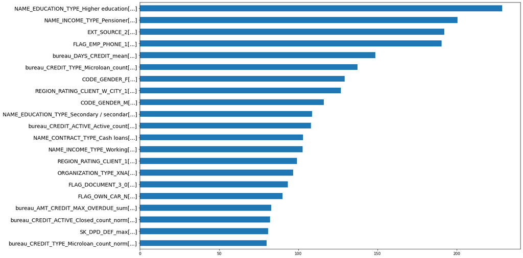

```python
xgb_feature_importance = modfit_xgb.get_booster().get_score(importance_type="gain")
xgb_feature_importance = pd.DataFrame.from_dict(xgb_feature_importance, orient = "index")
xgb_feature_importance.rename(columns = {0 : "importance"}, inplace = True)
xgb_feature_importance.sort_values("importance", ascending = True, inplace = True)
xgb_top_features = xgb_feature_importance.tail(21)
xgb_top_features.plot(figsize = (18, 12), kind = "barh")
plt.yticks(range(0,len(xgb_top_features.index)),
           xgb_top_features.index.map(lambda X : str(X[:40]) + "[...]"), fontsize = 14);
plt.legend().set_visible(False)
```

Cependant, cela n'indique pas comment la valeur de la variable influence le résultat, ni, pour une prédiction donnée, quels sont les éléments ayant mené à la valeur obtenue.

Pour cela, nous utiliserons l'interpréteur SHAP.

## Interpréteur shap

### Importance des variables

L'interpréteur SHAP nous permet d'obtenir l'importance des variables :

```python
explainer = shap.TreeExplainer(modfit_xgb)
```

```python
shap_values = explainer.shap_values(X2_comb_subtrain)
```

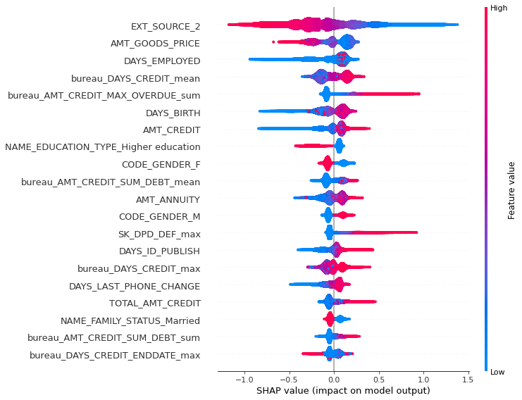

```python
shap.summary_plot(shap_values, X2_comb_subtrain)
```

Par exemple, AMT_GOOD_PRICE :

- Diminue fortement le risque de défaut quand sa valeur est élevée
- Augmente modérément le risque de défaut lorsque la valeur est faible

### Interprétation d'une prédiction

Pour une prédiction donnée, nous pouvons avoir une explication du résultat par un graphe en cascade. Nous montrerons ici 3 exemples sur 3 clients :

- Le client n°1 qui sera le premier client de notre set de test
- Le client n°2 qui est le client ayant le score le plus faible
- Le client n°3 qui est celui ayant le score le plus élevé

```python
background = shap.maskers.Independent(X2_comb_test)
def pred_wrapper(x):
    return shap.links.identity(modfit_xgb.predict_proba(x, validate_features=False)[:,1])
pred_explainer = shap.Explainer(pred_wrapper, background, link=shap.links.logit)

def get_waterfall(x):
    shap_pred_values = pred_explainer(x)

    # visualize the first prediction's explanation
    shap.plots.waterfall(shap_pred_values[0])
```

```python
client_1 = X2_comb_test.loc[X2_comb_test.index == 100002, :]
client_2 = X2_comb_test.loc[X2_comb_test.index == X2_comb_test.iloc[np.argmin(xgb_pred), :].name, :]
client_3 = X2_comb_test.loc[X2_comb_test.index == X2_comb_test.iloc[np.argmax(xgb_pred), :].name, :]
```

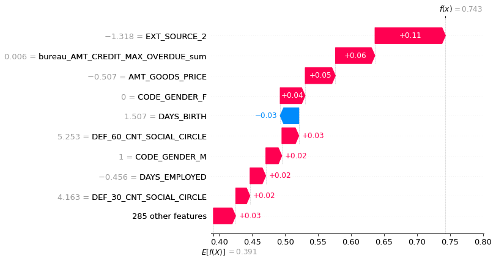

```python
get_waterfall(client_1)
```

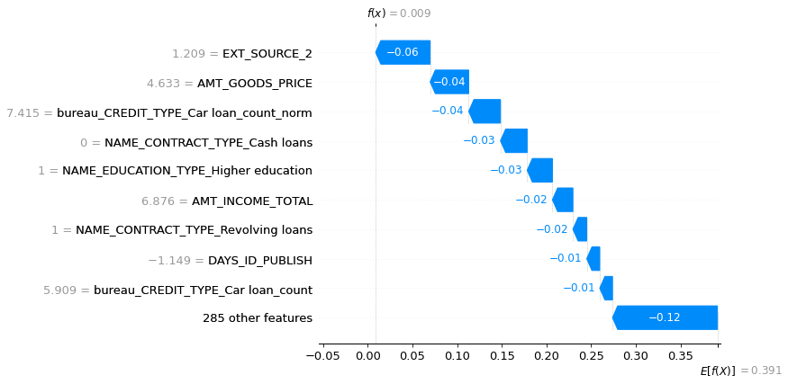

```python
get_waterfall(client_2)
```

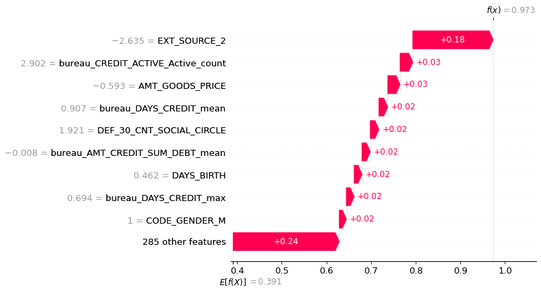

```python
get_waterfall(client_3)
```

Le modèle, le set préprocessé de test, et l'interpréteur SHAP font tous partie de l'API d'affichage de résultat